# assignment08

Author

Xiaohan Xie

```r
suppressPackageStartupMessages({
  library(epiwraps)
  library(ggplot2)
  library(AnnotationHub)
  library(ensembldb)
  library(edgeR)
  library(rtracklayer)
  library(BiocParallel)
  library(bsseq)   # Class and tools to analyze bisulfite sequencing data at CpG-level
  library(DMRcate) # Identification of differentially-methylated regions
})
```

## 1. Plot a heatmap of the methylation levels of the genes in top 5 DMR regions (from the practical) located on chr1.

Load the BSseq object:

```r
bs <- readRDS("ESC_astrocytes_BSseq.rds")
bs
```

```
An object of type 'BSseq' with
  748671 methylation loci
  4 samples
has not been smoothed
All assays are in-memory
```

```r
# remove CpGs that have 0 coverage in some samples:
bs <- bs[rowSums(assay(bs,"Cov")>0)==ncol(bs),]

design <- model.matrix(~celltype, data=pData(bs))
design
```

```
                       (Intercept) celltypeastrocytes
astrocytes_ENCFF001TPN           1                  1
astrocytes_ENCFF001TPP           1                  1
ESC_ENCFF001TMC                  1                  0
ESC_ENCFF001TMD                  1                  0
attr(,"assign")
[1] 0 1
attr(,"contrasts")
attr(,"contrasts")$celltype
[1] "contr.treatment"
```

```r
# adapt the design for methylation data: Each sample becomes two rows!
methdesign <- modelMatrixMeth(design)

bs <- BSmooth(bs, BPPARAM=MulticoreParam(4, progress=TRUE))
```

Load the DMR results from the practical, get the top5 DMR regions on chr1:

```r
dmrRanges <- readRDS("dmr.rds")
dmr_chr1 <- dmrRanges[seqnames(dmrRanges) == "chr1"]
dmr_chr1_top5 <- dmr_chr1[order(abs(dmr_chr1$meandiff), decreasing=TRUE)][1:5]
```

Get the genes on chr1, find overlaps with top5 DMR regions:

```r
genes <- readRDS("hg19_chr1_genes.rds")
genes_hits <- findOverlaps(genes, dmr_chr1_top5, type = "any")
genes_in_top_dmr <- genes[queryHits(genes_hits)]
```

Alternatively: we use the column overlapping.genes in the dmrRanges:

```r
gene_strings <- dmr_chr1_top5$overlapping.genes
gene_strings <- gene_strings[!is.na(gene_strings)]
gene_symbols <- unique(unlist(strsplit(gene_strings, ",\\s*")))
gene_symbols
```

```
[1] "CR1L"         "CD46P1"       "C1orf198"     "RP11-115D7.3"
```

```r
genes_in_top_dmr <- genes[genes$symbol %in% gene_symbols]
genes_in_top_dmr
```

```
GRanges object with 2 ranges and 2 metadata columns:
           seqnames              ranges strand |     gene_id      symbol
              <Rle>           <IRanges>  <Rle> | <character> <character>
      CR1L     chr1 207818458-207898053      + |        1379        CR1L
  C1orf198     chr1 230972865-231005335      - |       84886    C1orf198
  -------
  seqinfo: 93 sequences (1 circular) from hg19 genome
```

Plot the methylation levels:

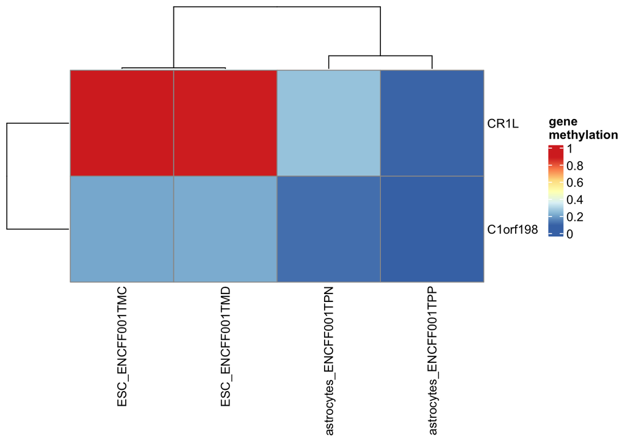

```r
met_genes <- bsseq::getMeth(bs, regions=genes_in_top_dmr, what="perRegion")
rownames(met_genes) <- genes_in_top_dmr$symbol
pheatmap(met_genes, name="gene\nmethylation")
```

## 2. Use the differentially-methylated regions from the practical, and compare those changes to changes in accessibility.

```r
download.file("https://www.ethz-ins.org/content/ATAC_AstroVsESC_subset.rds", "ATAC_AstroVsESC_subset.rds")
```

We first load the accessibility data:

```r
# To deal with an error when reading the rds file: Failed with error:  'there is no package called 'Seqinfo'' (probably because the RDS file was created under a different Bioc version)
# Updated R and Bioc to the newest version, where Seqinfo is separate
ATACRanges <- readRDS("ATAC_AstroVsESC_subset.rds")
dmrRanges <- dmrRanges[order(abs(dmrRanges$meandiff), decreasing=TRUE)]
```

To compare changes in methylation to changes in accessibility, we first find overlapping regions between DMR ranges and ATAC ranges, using findOverlaps, setting type = “within”. Then, we build a dataframe using the corresponding methylation mean difference and ATAC fold-change.

```r
# we find ATACRanges that have overlappings with dmr
ATAC_hits <- findOverlaps(ATACRanges, dmrRanges, type = "within")
matched_df <- data.frame(
  Meth_Diff = dmrRanges$meandiff[subjectHits(ATAC_hits)],
  ATAC_Diff = ATACRanges$logFC[queryHits(ATAC_hits)]
)
```

Finally, we visualise with a scatter plot to see how methylation mean difference and ATAC fold-change relate to each other.

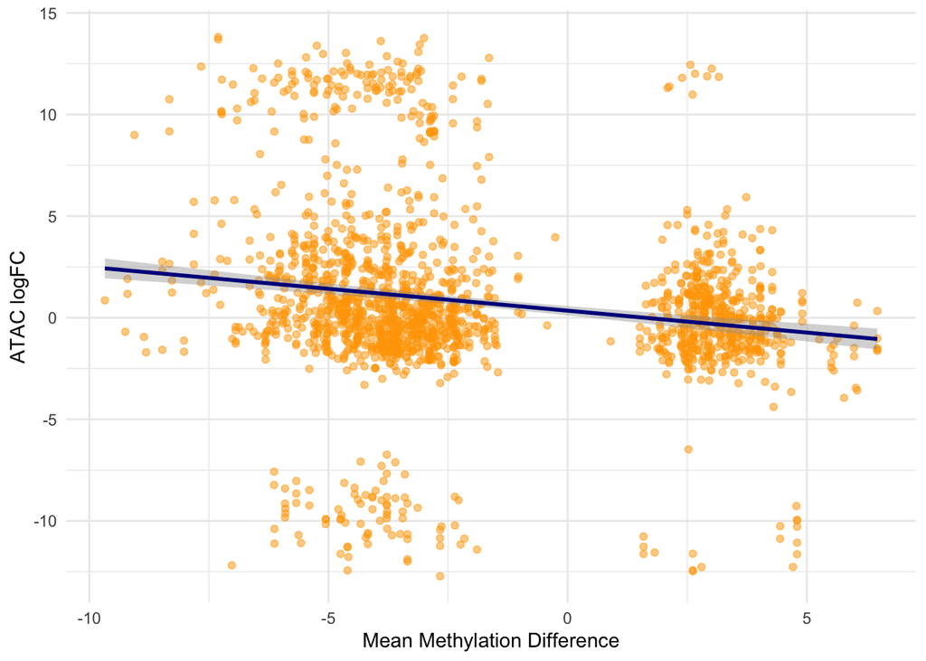

```r
ggplot(matched_df, aes(x=Meth_Diff, y=ATAC_Diff)) + geom_point(alpha=0.5, color= "orange")+geom_smooth(method = "lm", color = "darkblue") +
  theme_minimal() +
  labs(
    x = "Mean Methylation Difference",
    y = "ATAC logFC"
  )
```

The result shows a negative trend, supporting that DNA methylation is associated with low accessibility.